# Recommender Systems

Author

Dibanisa Fakude

# Authorship Declaration

I, Dibanisa Fakude, declare that:

1. This research report and the work presented in it, is my own.
2. I know that plagiarism is wrong. Plagiarism is to use another’s work and pretend that it is one’s own.
3. These calculations/report/plans are my own work.
4. I have not allowed and will not allow anyone to copy my work with the intention of passing it off as his or her own work.

Signature: ____________ D. Fakude

# 1. Overview

This project focuses on building a collaborative filtering recommender system to predict book ratings for users based on historical rating data. The system integrates various recommendation techniques, including item-based, user-based, and matrix factorization methods, to generate personalized book recommendations. By using a dataset of books, users, and their corresponding ratings, the project preprocesses data and computes similarities between books and users. Recommendations are made by predicting ratings for unseen books based on similar users or items. Additionally, the project employs ensemble methods to combine the predictions from different approaches to improve the overall recommendation accuracy, with an evaluation of the model’s performance using Root Mean Square Error (RMSE).

# 2. Exploratory Data Analysis

Based on the data below it is evident that 4 variables explain each book which are Title, Author ,Year of Publication and the publisher. The others are the images of each of the books.

```
Rows: 271,360
Columns: 8
$ ISBN                <chr> "0195153448", "0002005018", "0060973129", "0374157…
$ Book.Title          <chr> "Classical Mythology", "Clara Callan", "Decision i…
$ Book.Author         <chr> "Mark P. O. Morford", "Richard Bruce Wright", "Car…
$ Year.Of.Publication <chr> "2002", "2001", "1991", "1999", "1999", "1991", "2…
$ Publisher           <chr> "Oxford University Press", "HarperFlamingo Canada"…
$ Image.URL.S         <chr> "http://images.amazon.com/images/P/0195153448.01.T…
$ Image.URL.M         <chr> "http://images.amazon.com/images/P/0195153448.01.M…
$ Image.URL.L         <chr> "http://images.amazon.com/images/P/0195153448.01.L…
```

ISBN numbers and User IDs were numerical, so adding prefixes helped clarify what they represented, which was important when constructing matrix data. R would automatically add an “X” if a column or row was numeric, so adding the prefixes prevented this problem.

## 2.1 Visualizing the data distribution

Figure below shows how the ratings are distributed. Its is evident that most of the ratings are zero which might means the absence of rating meaning that the users read the book and not gave any rating. So to simplify the algorithm and avoid the skewing from the zeros ,only non zero values were taken in to account.

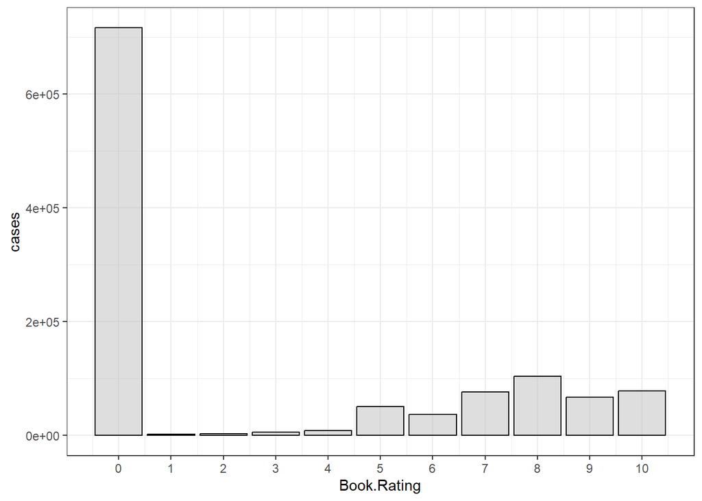

The plot below shows the top 10 rated books, it is evident that book Isbn.0316666343 has the most rating meaning most of the user has atleast rated the book by 1 or more. However this plot doesn’t show if the book with the most rating was badly rated or best rated.

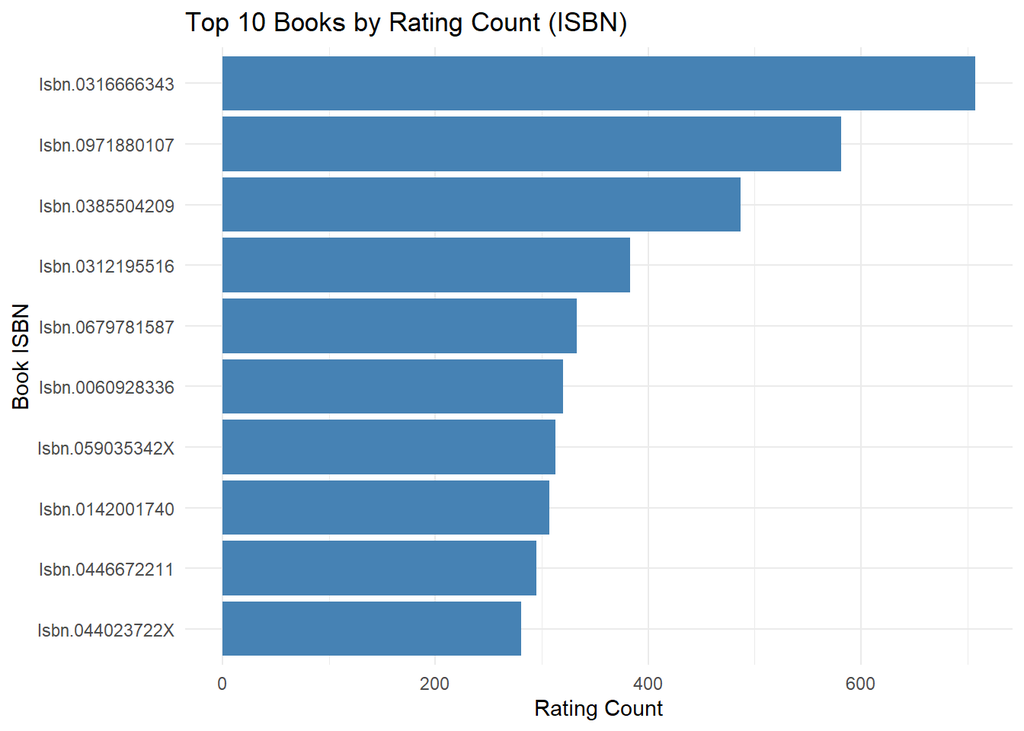

Figure below shows the books with the most rating that are 5 or more which means this books were rated moderately and good meaning the users enjoyed the book and more other users with the same taste were interested as well. This shows that these books will highly like appear in most recommendation.

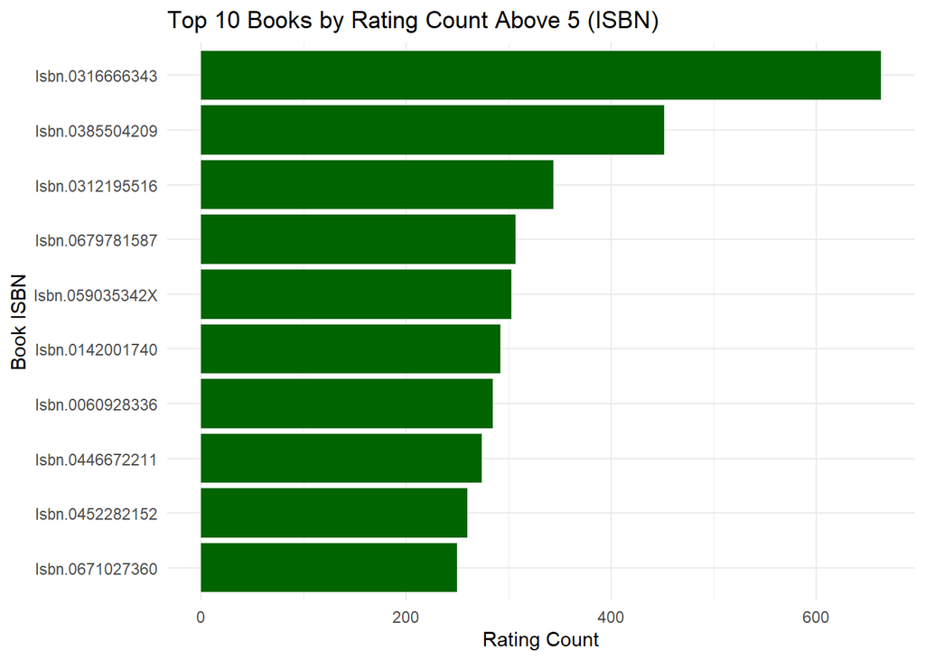

Figure below shows the distribution of the data after removing all the zero . Most of these books were rated 8 out of 10 which means most of the existing users liked the recommended books. Its also evident that very few users rated the books with 4 or less which means they were not interested in the book or they did not find it intresting.

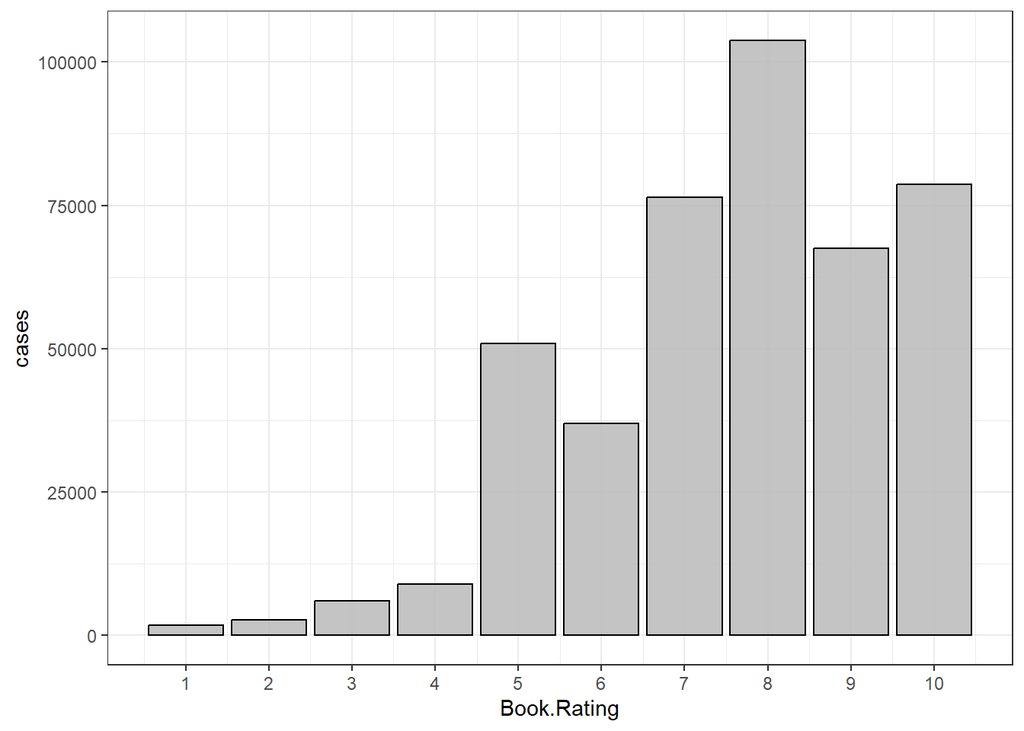

## 2.2. Data Statistics

```
    Min.  1st Qu.   Median     Mean  3rd Qu.     Max.
   1.000    1.000    1.000    5.574    3.000 8524.000
```

## 2.3. Data Filtering

To further reduce the data for computational needs top 10 000 ratings were selected and to code user based and item based collaborative filtering the data was reshaped to a matrix where rows are users and columns are books with values being user ratings, the reason for matrix is because collaborative filtering algorithms rely heavily on similarity.

```
            Isbn.0060096195 Isbn.0142302198 Isbn.038076041X Isbn.0699854289
User.276822              10              10              10              10
User.276847              NA              NA              NA              NA
User.276859              NA              NA              NA              NA
User.276861              NA              NA              NA              NA
User.276872              NA              NA              NA              NA
            Isbn.0786817070
User.276822              10
User.276847              NA
User.276859              NA
User.276861              NA
User.276872              NA
```

```
[1] 0.9998194
```

# 3. Calculating similarity

**Cosine similarity**, was calculated to measure how closely related two users or two items were based on their ratings. In this context, **cosine similarity** quantified the angle between two vectors (user or item rating profiles), producing values from -1 (completely dissimilar) to 1 (perfectly similar). This calculation was essential in collaborative filtering, as recommendations were generated by identifying users with similar preferences (in **user-based CF**) or items that were rated similarly (in **item-based CF**). By determining similarity, items that users with similar profiles liked were suggested, or predictions were made about which items a user might prefer based on their similarity to other items.

## 3.1. Item Based Collaborative Filtering

## 3.1.1. For existing users

The first algorithm explored was item based collaborative filtering. Item-based techniques first examined the user-item matrix to identify relationships among different items, and then utilized these relationships to indirectly generate recommendations for users (Sarwar et al. 2001).

Using the algorithm to recommend books that are similary to book Isbn.0399135782 (as a test) results of the item-based algorithm recommended other books sharing a similarity score of approximately **0.577**. This consistent score suggests a moderate level of similarity among these books based on user ratings.

The books showed the same similarity score which implies that they are likely to be clustered together in terms of user preferences. Users who rated one of these books similarly are expected to have similar tastes regarding the others. Consequently, this result indicates that the item-based collaborative filtering approach effectively identified relationships between items, enabling the generation of relevant recommendations for users who enjoyed any of the listed books.

```
# A tibble: 6 × 2
  ISBN            similarity
  <chr>                <dbl>
1 Isbn.031218008X      0.577
2 Isbn.0394507614      0.577
3 Isbn.0394524128      0.577
4 Isbn.0877225761      0.577
5 Isbn.0345359321      0.577
6 Isbn.0140622160      0.577
```

## 3.1.2. For new users

The algorithm described was specifically designed for those already present in the dataset and did not account for new users or those who have never rated any items before. The output below displays the similarities of various books calculated based on the default books and ratings provided to help address the cold start problem for new users. The results indicated a range of similarity scores, with the highest being **0.625**, which suggest a moderate relationship between the first book and the provided default books.

The subsequent books have lower similarity scores, with majority clustered around **0.141**, indicating weaker relationships. This variation in similarity scores demonstrates that while some default books share a closer connection based on user ratings, others may not align as well.

```
# A tibble: 27 × 2
   ISBN            similarity
   <chr>                <dbl>
 1 Isbn.0699854289      0.625
 2 Isbn.1573248533      0.442
 3 Isbn.0060537256      0.141
 4 Isbn.0060537264      0.141
 5 Isbn.0060561572      0.141
 6 Isbn.0060561580      0.141
 7 Isbn.0064410862      0.141
 8 Isbn.0064410889      0.141
 9 Isbn.0064410897      0.141
10 Isbn.0064410900      0.141
# ℹ 17 more rows
```

# 3.2. User based Collaborative filtering

User-based collaborative filtering forecasts a test user’s interest in a specific item by utilizing rating data from similar user profiles (Wang, De Vries, and Reinders 2006).

The output below from the user-based collaborative filtering algorithm is for existing users, it indicates top book recommendations for User.276822, along with their respective rating counts and average ratings. **Isbn.0312278586** and **Isbn.0316096199** both received an average rating of **9.0** from two different users, indicating strong consensus regarding their quality. Similarly, **Isbn.0345337662** achieved an average rating of **6.5**, also from two users. These recommendations reflected the preferences of similar users, meaning that User.276822 may enjoy these titles based on the high ratings received from peers with comparable tastes.

```
# A tibble: 3 × 3
  ISBN            count Book.Rating
  <chr>           <int>       <dbl>
1 Isbn.0312278586     2         9
2 Isbn.0316096199     2         9
3 Isbn.0345337662     2         6.5
```

## 3.2.1. For new users

The results below are obtained from a new user, as a starting point the algorithm set default books and ratings. The algorithm identified **Isbn.0699854289** as the most similar book with a high similarity score of **0.6251**, indicating a strong relationship with the default ratings provided. This suggests that users who rated this book similarly to the default ratings also showed a preference for it.

Following this, **Isbn.1573248533** scored **0.4420**, showed a moderate level of similarity, while the remaining titles each had a lower similarity score of **0.1414**. The consistency of these results from both the user-based and item-based algorithm indicates a robust recommendation system that can effectively suggest relevant books even for new users.

```
# A tibble: 5 × 2
  ISBN            similarity
  <chr>                <dbl>
1 Isbn.0699854289      0.625
2 Isbn.1573248533      0.442
3 Isbn.0060537256      0.141
4 Isbn.0060537264      0.141
5 Isbn.0060561572      0.141
```

# 3.3. Matrix factorization

Many traditional collaborative filtering approaches struggle with handling very large datasets and managing users who have provided very few ratings. However, the Matrix Factorization model scales linearly with the number of observations and excels at working with large, sparse, and highly imbalanced datasets (Mnih and Salakhutdinov 2007).

To perform the matrix factorization, the data was first split into 80% training and 20% testing sets. The model was then applied to the training data using the **recosystem** library, with its performance evaluated based on the Root Mean Squared Error (RMSE) to assess the accuracy of the recommendation model. The first model was trained without applying regularization, while the second was trained with regularization to compare potential improvements or differences between these models.

The results show that the model without regularization achieved a slightly higher RMSE (2.5749) compared to the model with regularization (2.5704). Although the difference is minimal, it suggests that the regularization helped in controlling overfitting by slightly improving the model’s performance in terms of RMSE. Additionally, both models saw significant reductions in training RMSE across iterations, with the RMSE steadily decreasing from 5.1556 in the first iteration to below 1.0 by iteration 19. This trend indicates that the models effectively minimized error as they learned from the training data.

```
iter      tr_rmse          obj
   0       5.1556   7.7017e+06
   1       2.5416   2.2222e+06
   2       1.7416   1.3060e+06
   3       1.4031   1.0240e+06
   4       1.2311   9.0572e+05
   5       1.1338   8.4460e+05
   6       1.0710   8.0889e+05
   7       1.0250   7.8376e+05
   8       0.9876   7.6396e+05
   9       0.9561   7.4776e+05
  10       0.9289   7.3389e+05
  11       0.9049   7.2198e+05
  12       0.8835   7.1140e+05
  13       0.8644   7.0225e+05
  14       0.8472   6.9402e+05
  15       0.8314   6.8628e+05
  16       0.8172   6.7984e+05
  17       0.8041   6.7345e+05
  18       0.7920   6.6781e+05
  19       0.7809   6.6272e+05
```

```
[1] "RMSE without regularization: 2.57491333022872"
```

```
iter      tr_rmse          obj
   0       5.1496   7.6868e+06
   1       2.5381   2.2172e+06
   2       1.7401   1.3050e+06
   3       1.4016   1.0232e+06
   4       1.2298   9.0489e+05
   5       1.1328   8.4457e+05
   6       1.0704   8.0853e+05
   7       1.0248   7.8418e+05
   8       0.9876   7.6441e+05
   9       0.9566   7.4793e+05
  10       0.9299   7.3476e+05
  11       0.9059   7.2280e+05
  12       0.8844   7.1212e+05
  13       0.8657   7.0278e+05
  14       0.8484   6.9467e+05
  15       0.8329   6.8726e+05
  16       0.8187   6.8047e+05
  17       0.8054   6.7394e+05
  18       0.7936   6.6858e+05
  19       0.7822   6.6331e+05
```

```
[1] "RMSE with regularization: 2.57039577180505"
```

## 3.3.1. Recommending using the matrix Factorization

## -For existing users

The results below from the matrix factorization model with regularization shows the predicted ratings for specific books for an existing user. In this case, the predicted top 5 ratings for the ISBNs listed are all equal to 10, which is the maximum rating in the dataset. This suggests that the model identified these books as highly relevant or favorable for the user, likely based on the patterns and similarities found in the training data. The uniformity of the predicted ratings indicates that these books are strongly recommended for the user based on the learned user-item interactions

```
               ISBN Predicted_Rating
338 Isbn.0004708717               10
353 Isbn.000599134X               10
368 Isbn.0006137962               10
433 Isbn.0006169015               10
466 Isbn.0006175015               10
```

## .3.3.2. For new user

The results for the new user, who was assigned default books and ratings, illustrated the predicted ratings for several titles based on the initial data provided. The predicted ratings ranged from approximately 6.44 to 6.66, indicating that the model considered these books to be moderately appealing to the user. By assigning default ratings, the recommendation system established a baseline for the user’s preferences, allowing it to identify relevant books within the dataset. This approach enabled the model to leverage existing relationships among items and user ratings, providing a tailored set of recommendations even for users without a prior rating history. The predicted ratings suggested that the recommended books were likely to resonate with the new user, setting the stage for future interactions and more refined recommendations as the user began to engage with the system.

```
iter      tr_rmse          obj
   0       5.1477   7.6807e+06
   1       2.5379   2.2163e+06
   2       1.7399   1.3042e+06
   3       1.4013   1.0233e+06
   4       1.2301   9.0547e+05
   5       1.1328   8.4478e+05
   6       1.0704   8.0887e+05
   7       1.0244   7.8350e+05
   8       0.9879   7.6419e+05
   9       0.9567   7.4809e+05
  10       0.9293   7.3411e+05
  11       0.9060   7.2262e+05
  12       0.8845   7.1202e+05
  13       0.8653   7.0253e+05
  14       0.8478   6.9437e+05
  15       0.8320   6.8661e+05
  16       0.8178   6.8008e+05
  17       0.8046   6.7408e+05
  18       0.7919   6.6780e+05
  19       0.7810   6.6272e+05
```

```
# A tibble: 5 × 2
  ISBN            Predicted_Rating
  <chr>                      <dbl>
1 Isbn.0674194241             6.66
2 Isbn.0312952236             6.48
3 Isbn.1891620614             6.44
4 Isbn.0892839007             6.44
5 Isbn.044021256              6.44
```

# 4. Ensemble Collaborative filtering

Ensemble collaborative filtering is a recommendation method that merges multiple recommendation techniques to enhance the overall accuracy and performance of predictions. In this case, user-based, item-based, and matrix factorization algorithms were combined to create a single final model. The model applied predefined weights to balance the influence of each algorithm on the final recommendations. Here, user-based filtering was assigned the highest weight of 0.4, while both item-based and matrix factorization were given equal weights of 0.3 each. For example, if user-based filtering generates a score of 1.5, item-based provides 1.0, and matrix factorization yields 1.1, the final combined score reflects the sum of these contributions, adjusted according to their assigned weights, to produce a balanced recommendation.

The output presents a total score for each ISBN, indicating the relevance of the recommended books to the target user. The scores range from 0.1732051 to 3.6, with higher scores suggesting a stronger likelihood that the user will appreciate these titles. This score is a weighted average of the results from the three algorithms, designed to reflect the user’s potential interest in each book.

```
# A tibble: 10 × 2
   ISBN            Total_Score
   <chr>                 <dbl>
 1 Isbn.0312278586       3.6
 2 Isbn.0316096199       3.6
 3 Isbn.0004708717       3
 4 Isbn.000599134X       3
 5 Isbn.0006137962       3
 6 Isbn.0006169015       3
 7 Isbn.0006175015       3
 8 Isbn.0345337662       2.6
 9 Isbn.0140622160       0.173
10 Isbn.031218008X       0.173
```

## References

Mnih, Andriy, and Russ R Salakhutdinov. 2007. “Probabilistic Matrix Factorization.” *Advances in Neural Information Processing Systems* 20.

Sarwar, Badrul, George Karypis, Joseph Konstan, and John Riedl. 2001. “Item-Based Collaborative Filtering Recommendation Algorithms.” In *Proceedings of the 10th International Conference on World Wide Web*, 285–95.

Wang, Jun, Arjen P De Vries, and Marcel JT Reinders. 2006. “Unifying User-Based and Item-Based Collaborative Filtering Approaches by Similarity Fusion.” In *Proceedings of the 29th Annual International ACM SIGIR Conference on Research and Development in Information Retrieval*, 501–8.